# Module 03 - In Class

Ethan Gutknecht

2/22/2022

# Question 1:

In a controlled environment laboratory, 10 men and 10 women were tested to determine the room temperature they found to be the most comfortable. Assuming that the temperatures resemble a random sample from their respective populations, is the median comfortable temperature the same for men and women? Use the Mann-Whitney test. Use = 0.05

```r
# Get Data;
q1men <- c(74, 72, 77, 76, 76, 73, 75, 73, 74, 75)
q1women <- c(75, 77, 78, 79, 77, 73, 78, 79, 78, 80)
```

### Part I:

Why might the Mann-Whitney test be preferred to the two independent samples t-test for these data?

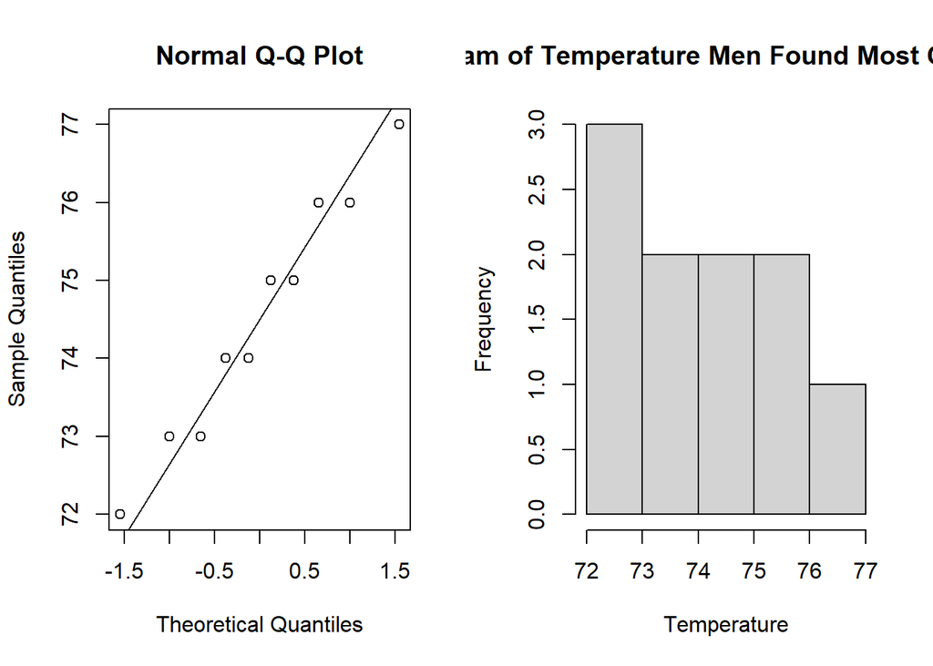

```r
# Create graphics to prove that they are not normal

par(mfrow=c(1,2))
qqnorm(q1men)
qqline(q1men)
hist(q1men, main = "Histogram of Temperature Men Found Most Comfortable", xlab = "Temperature", ylab = "Frequency")
```

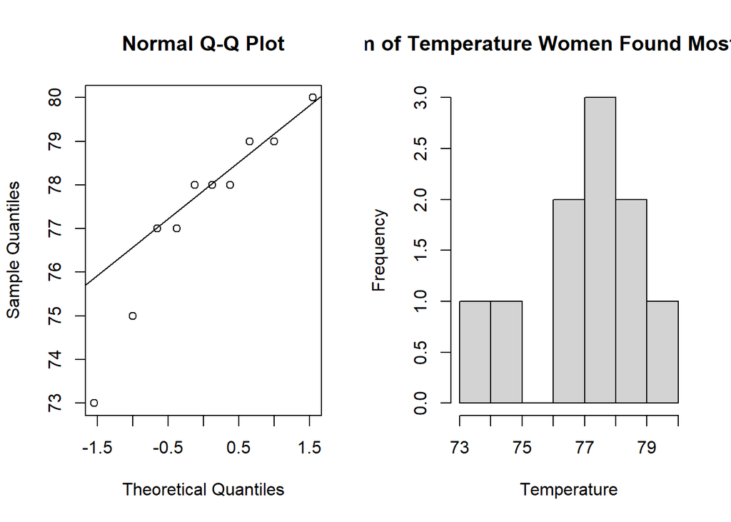

```r
par(mfrow=c(1,2))
qqnorm(q1women)
qqline(q1women)
hist(q1women, main = "Histogram of Temperature Women Found Most Comfortable", xlab = "Temperature", ylab = "Frequency")



# Density Plot
library(ggpubr)
```

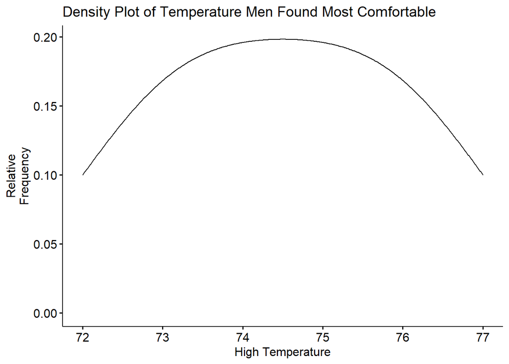

```r
ggdensity(q1men, xlab ="High Temperature", ylab="Relative
Frequency", main="Density Plot of Temperature Men Found Most Comfortable")
```

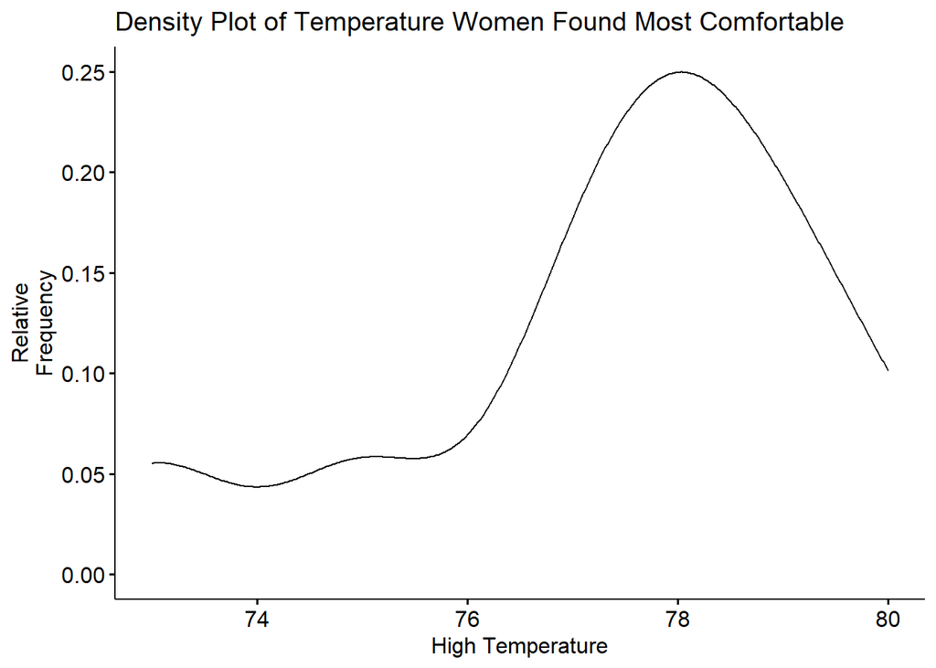

```r
ggdensity(q1women, xlab ="High Temperature", ylab="Relative
Frequency", main="Density Plot of Temperature Women Found Most Comfortable")
```

Based on these plots, one of the requirements for the two sample t-test is for both populations to be normally distributed. As we can see from density plot of the women’s population, we can see that the population is not normally distributed.

### Part II:

Label the parameter

Let M1 be the median comfortable room temperature for men. Let M2 be the median comfortable room temperature for women.

### Part III:

State null and alternative hypotheses

$H_{0}$: M1 = M2

$H_{a}$: M1 $\neq$ M2

### Part IV:

Compute a test statistic and p-value using R

```r
# Compute the test stat in R
library(coin)
library(exactRankTests)
wilcox.exact(q1men, q1women, alternative = "two.sided", paired = FALSE, conf.level = 0.95)
```

```
##
##  Exact Wilcoxon rank sum test
##
## data:  q1men and q1women
## W = 13, p-value = 0.003237
## alternative hypothesis: true mu is not equal to 0
```

### Part V:

Since the p-value of 0.003237 is less than our alpha value of 0.05, our test rejects the null hypothesis and we have sufficient evidence that the median of the comfortable temperature for men differ from the median of the comfortable temperature for women.

# Question 2:

A blood bank kept a record of the rate of heartbeats for several blood donors. Is the variation among the men significantly greater than the variation among the women? Use the Ansari-Bradley test. Use = 0.05

### Part I:

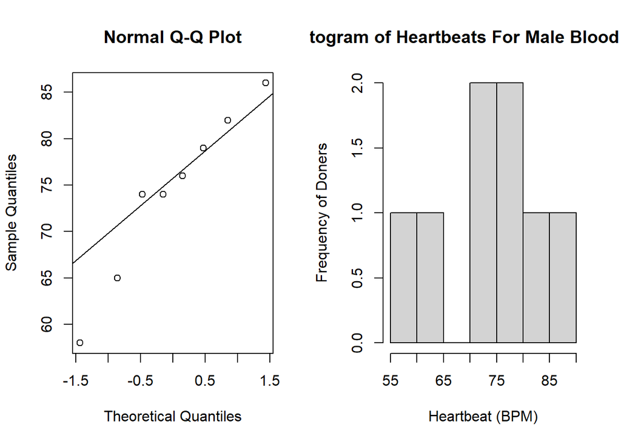

```r
# Get Data;
q2men <- c(58, 76, 82, 74, 79, 65, 74, 86)
q2women <- c(66, 74, 69, 76, 72, 73, 75, 67, 68)

# Load Package For Density Plot
library(ggpubr)

# See if data will fit this test for first population
par(mfrow=c(1,2))
qqnorm(q2men)
qqline(q2men)
hist(q2men, main = "Histogram of Heartbeats For Male Blood Doners",
xlab = "Heartbeat (BPM)", ylab = "Frequency of Doners")
```

[figure not shown]

```r
ggdensity(q2men, xlab ="Heartbeat (BPM)", ylab="Relative
Frequency", main="Histogram of Heartbeats For Female Blood Doners")
```

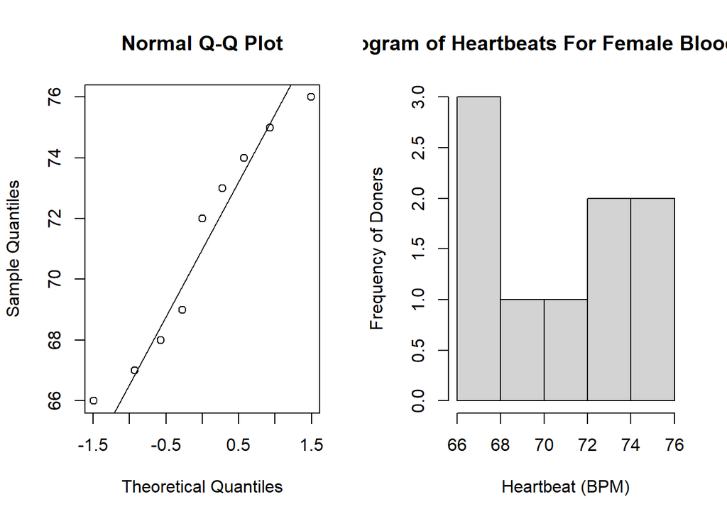

```r
## See it for the other population
qqnorm(q2women)
qqline(q2women)
hist(q2women, main = "Histogram of Heartbeats For Female Blood Doners",
xlab = "Heartbeat (BPM)", ylab = "Frequency of Doners")
```

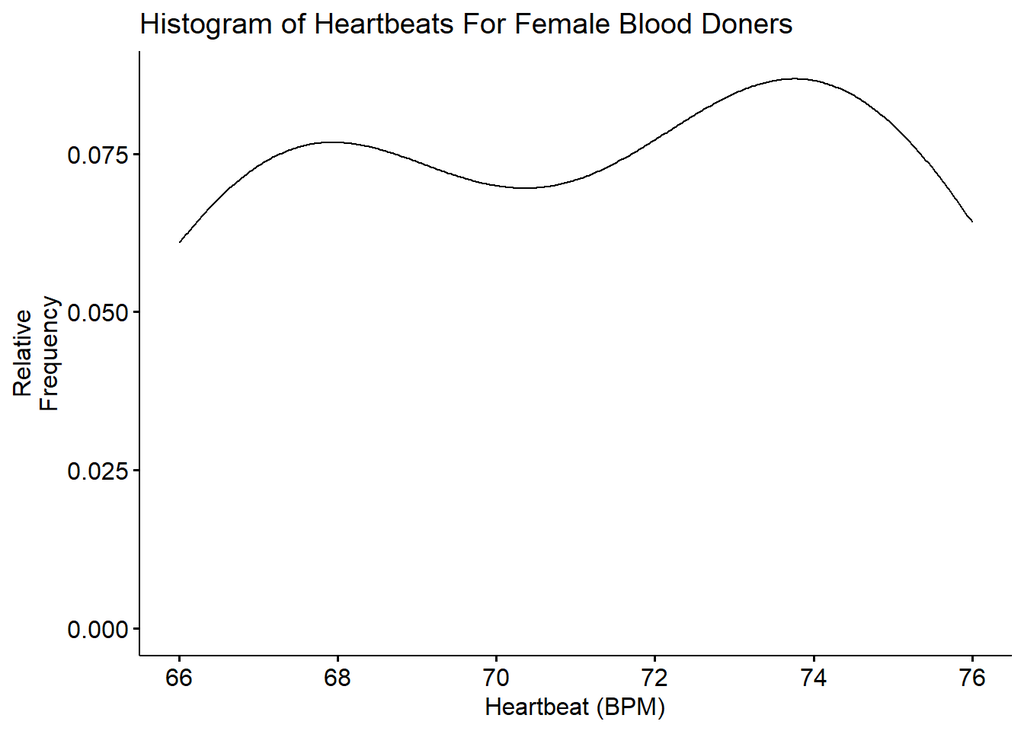

```r
ggdensity(q2women, xlab ="Heartbeat (BPM)", ylab="Relative
Frequency", main="Histogram of Heartbeats For Female Blood Doners")
```

Neither population is normally distributed so we cannot use the F-test. Thus, our next best option is the Ansari-Bradley test.

### Part II:

Label the parameters.

Let $sigma_{m}$ be the true dispersion parameter for the overall BPM measurement for men.

Let $sigma_{w}$ be the true dispersion parameter for the overall BPM measurement for women.

### Part III:

State null and alternative hypotheses.

$H_{0}$: $\sigma_{m}$ = $\sigma_{w}$

### Part VI:

Compute a test statistic and p-value using R.

```r
median(q2men)
```

```
## [1] 75
```

```r
median(q2women)
```

```
## [1] 72
```

```r
# Since the difference of medians is 3, we add three to each.
q2women <- q2women + 3

# Perform test.
library(coin)
library(exactRankTests)
ansari.exact(q2men, q2women, alternative = "two.sided")
```

```
##
##  Ansari-Bradley test
##
## data:  q2men and q2women
## AB = 32, p-value = 0.2555
## alternative hypothesis: true ratio of scales is not equal to 1
```